# Final Report Draft (Python)

Authors

Sean Leader

William Medwid

Vanessa Veto

Jose Mierzejewski

# Introduction

The EPA is an organization fundamentally invested securing and promoting the health and well-being of the environment. In this paper, we analyze two distinct but related environmental issues: air pollution and car dependency. For both issues, we used publicly available data sourced from the EPA to construct machine learning models to make predictions. For air pollution, we predicted a county’s next-day Air Quality Index (AQI) from the previous day’s atmospheric conditions to determine which factors contribute to AQI and how accurately we can determine tomorrow’s AQI from today’s conditions. For car dependency, we predicted the ‘walkability’ category of a localized area based on demographic information to deduce which demographic characteristics contribute most meaningfully to the ‘walkability’ of a location.

# Data Collection & Description

## AQI

To collect information about atmospheric conditions and Air Quality Index, we downloaded two years (2021 & 2022) worth of atmospheric data from the EPA (source in the appendix). These data were collected by various monitoring stations across 43 counties in 32 states across the United States on a daily basis. In the final data set, one observation corresponded to one day of atmospheric measurements for a particular county, with multiple measurements from different weather stations. We had to omit some of the observations because predicting next-day AQI from current-day atmospheric conditions requires sequential days where all atmospheric measurements at that monitoring station are present. Sequential days that were missing any of the atmospheric measurements on either day were omitted from the data.

**There are different AQIs for different atmospheric pollutants. For this project, we chose to predict the AQI based on ozone from atmospheric conditions (excluding ozone concentration) because the ozone AQI was the most frequent of the different AQIs after all data merging was complete.**

**For each atmospheric measurement, we extracted the minimum, average, and maximum measurement at each weather station each day.** The following table details the atmospheric measurements we extracted.

| Variable Name | Variable Description |
| --- | --- |
| no2 | Atmospheric Concentration of Nitrogen Dioxide (ppb) |
| co | Atmospheric Concentration of Carbon Monoxide (ppm) |
| so2 | Atmospheric Concentration of Sulfur Dioxide (ppb) |
| no | Atmospheric Concentration of Nitrogen Monoxide (ppb) |
| temp | Temperature (Celsius) |
| wind | Wind Speed (knots) |
| pressure | Barometric Pressure (millibars) |
| humid | Relative Humidity (% rh) |
| AQI | Next-day Air Quality Index, measured by Ozone |

Table 1. Variable summary for AQI dataset

## Walkability

Data about walkability was accessed from the U.S. Government’s open data catalog, data.gov. The data was collected by the Environmental Protection Agency (EPA) and contains demographic information, built environment characteristics, and transportation infrastructure data from 2021 for each Census block group. These inputs are used to calculate the National Walkability Index as defined by the EPA. This index can be expressed either numerically or translated into qualitative categories (see Table 2 below)

[figure not shown]

In total, there are 220,740 observations for 117 variables in this dataset. Since there were so many predictors to choose from, we narrowed it down to those in the table below (more details on variable selection in the Exploratory Data Analysis section).

[figure not shown]

# Exploratory Data Analysis

## AQI

### Overall distribution of AQI

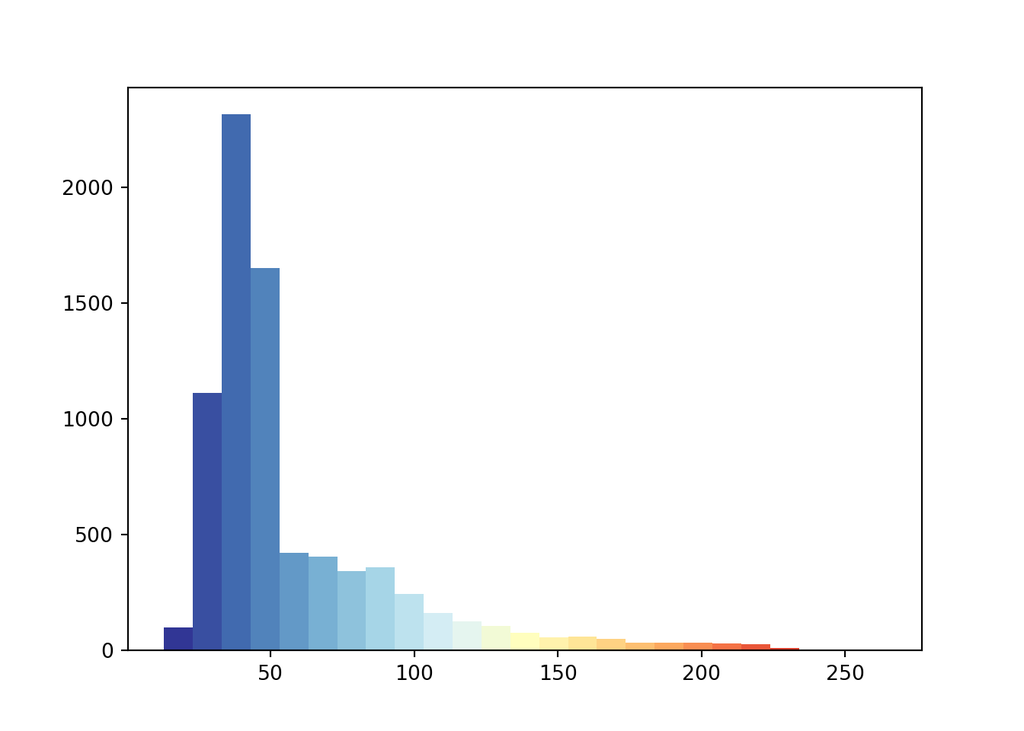

Figure 1. Overall distribution of AQI

| Mean      | SD      | Median      | IQR      |
| --- | --- | --- | --- |
| 59 | 36 | 44 | 30 |

Table 2. Summary statistics of AQI

Overall, the distribution of AQI scores is single-peaked and right-skewed, with a median next-day AQI of 44 and an interquartile range of 30. The graph is likely right-skewed because AQI is bounded on the lower end by 0, but has no upper limit.

### Overall distribution of AQI by month

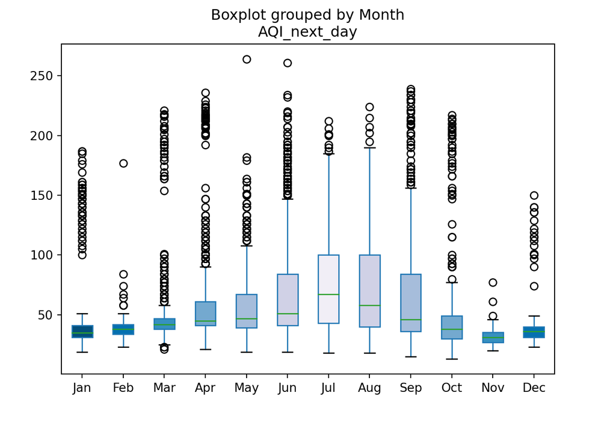

Figure 2. Distribution of AQI by month

Figure 2 reveals the seasonal trend in AQI. AQI tends to be higher in the summer months and lower in the winter months for these data. The exact mechanism for this relationship is unknown, but some hypotheses include:

1. Extreme heat and stagnant air can lead to an increase in ground-level ozone concentrations
2. Hot and dry weather results in forest fires that can increase atmospheric pollutants
3. Clouds are less common at higher temperatures but are important for preventing the production of ozone

### Correlations between predictors and AQI

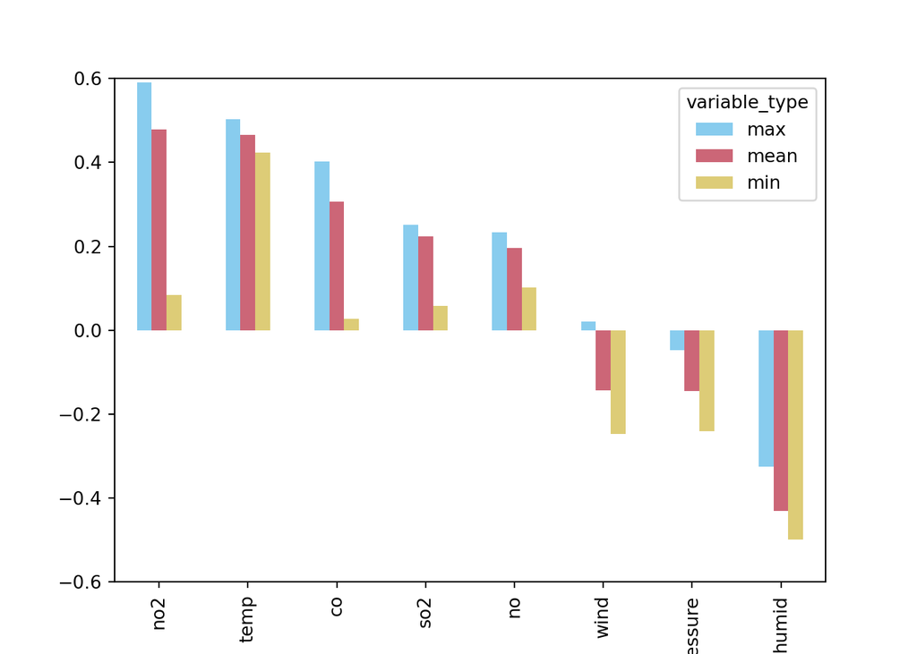

Figure 3. Predictor correlations with AQI, by min, mean, and max concentration